# Metabolomics Data Sharing

Analysis by Rachel Spicer, github:RASpicer

2017/10/13

# 1 R Markdown

This RMarkdown contains the code used for analysis for the 2017 paper **Journals promote metabolomics data sharing: does it work?**

# 2 Publications linked to Open Data

Studies from each of the repositories GNPS, MetaboLights, Metabolomic Workbench, MetaPhen and MeRy-B were manually reviewed to find associated publications. All studies with publicly available data in one of these repositories are listed in **AllPublicationswithPublicData.csv**.

```r
OpenDataPub <- read.csv("../AllPublicationswithPublicData.csv", stringsAsFactors = FALSE,
    check.names = F)

# Find all unique DOIS
UniqueDOI <- unique(OpenDataPub$DOI)

# Extract only non duplicated DOIs
DuplicatedDOI <- duplicated(OpenDataPub$DOI)
NonDupPub <- OpenDataPub[!DuplicatedDOI, ]

# Create and order table of journals with the highest frequency of
# metabolomics Publications
OpenDataJournals <- as.data.frame(table(NonDupPub$Journal))
OpenDataJournalsOrder <- OpenDataJournals[order(-OpenDataJournals$Freq), ]
colnames(OpenDataJournalsOrder) <- c("Journal", "Frequency")
kable(OpenDataJournalsOrder, row.names = FALSE, caption = "The journals with the highest frequency of publications directly linked from a publicly available metabolomics study, in a dedicated metabolomics repository.",
    align = "l")
```

The journals with the highest frequency of publications directly linked from a publicly available metabolomics study, in a dedicated metabolomics repository.

| Journal | Frequency |
| --- | --- |
| Metabolomics | 53 |
| PLoS One | 27 |
| Plant Physiology | 19 |
| PNAS | 14 |
| Scientific Reports | 13 |
| Journal of Proteome Research | 11 |
| The Plant Journal | 10 |
| Analytical Chemistry | 8 |
| Nature Communications | 6 |
| Plant, Cell & Environment | 6 |
| Journal of Biological Chemistry | 5 |
| Metabolites | 5 |
| Analytica Chimica Acta | 4 |
| Analytical and Bioanalytical Chemistry | 4 |
| Journal of Experimental Botany | 4 |
| Nature | 4 |
| Plant Physiology | 4 |
| Rapid Communications in Mass Spectrometry | 4 |
| Scientific Data | 4 |
| BMC Plant Biology | 3 |
| Cancer Research | 3 |
| Frontiers in Bioengineering and Biotechnology | 3 |
| Frontiers in Microbiology | 3 |
| Frontiers in Plant Science | 3 |
| International Journal of Molecular Sciences | 3 |
| Molecular BioSystems | 3 |
| The Plant Cell | 3 |
| ACS Chemical Biology | 2 |
| Antimicrobial Agents and Chemotherapy | 2 |
| Bioinformatics | 2 |

[output cut: 116 more lines]

# 3 PubMed Data

When searching PubMed for journal articles, reviews and systematic reviews are also returned. PubMed was searched to find metabolomics papers using “metabolome” OR “metabolomics”. On the 15th September 2017, there were:

- 21230 journal articles (including reviews) (“metabolomics”[MeSH Terms] OR “metabolomics”[All Fields]) OR (“metabolome”[MeSH Terms] OR “metabolome”[All Fields]) AND Journal Article[ptyp]
- 3498 review articles (“metabolomics”[MeSH Terms] OR “metabolomics”[All Fields]) OR (“metabolome”[MeSH Terms] OR “metabolome”[All Fields]) AND Review[ptyp]
- 228 systematic review articles (“metabolomics”[MeSH Terms] OR “metabolomics”[All Fields]) OR (“metabolome”[MeSH Terms] OR “metabolome”[All Fields]) AND systematic[sb])
- 3608 (“metabolomics”[MeSH Terms] OR “metabolomics”[All Fields]) OR (“metabolome”[MeSH Terms] OR “metabolome”[All Fields]) AND (systematic[sb] OR Review[ptyp])

These PubMed search histories were then downloaded using FLink (https://www.ncbi.nlm.nih.gov/Structure/flink/flink.cgi). Due the FLink being only able to download 10,000 citations at a time, the 21230 journal articles were downloaded in 3 sets then recombined.

Reviews and Systematic Reviews where then removed from further analysis, leaving a total of 17614. 17614 is then the rough estimate of the total number of primary research articles.

```r
# Read csv of all pubmed records
PubmedAll1 <- read.csv("../PubMedAll19902009.csv", stringsAsFactors = FALSE,
    check.names = FALSE)
PubmedAll2 <- read.csv("../PubMedAll20102014.csv", stringsAsFactors = FALSE,
    check.names = FALSE)
PubmedAll3 <- read.csv("../PubmedAllJournalArticles.csv", stringsAsFactors = FALSE,
    check.names = FALSE)
PubmedSysReview <- read.csv("../PubmedAllSystematicReviews.csv", stringsAsFactors = FALSE,
    check.names = FALSE)
PubmedReview <- read.csv("../PubmedAllReviews.csv", stringsAsFactors = FALSE,
    check.names = FALSE)

# Combine older and newer records for searching '('metabolomics'[MeSH Terms]
# OR 'metabolomics'[All Fields]) OR ('metabolome'[MeSH Terms] OR
# 'metabolome'[All Fields]) AND Journal Article[ptyp]' in PubMed
PubmedRec <- rbind(PubmedAll1, PubmedAll2, PubmedAll3)

# Extract review articles and remove them from the dataset Remove reviews
Reviews <- (PubmedRec$UID %in% PubmedReview$UID)
Pubmedminusreview <- PubmedRec[!Reviews, ]
# Remove systematic reviews
SysRev <- (Pubmedminusreview$UID %in% PubmedSysReview$UID)
PubmedminusSysreview <- Pubmedminusreview[!SysRev, ]
# Remove duplicated rows
Pubmedunique <- unique(PubmedminusSysreview)
```

## 3.1 Extract Journal Information

Which journal each paper was published in was then extracted using regex. However this did not always extract just the journal title.

The dataset was manually checked to ensure that the journal was correct for each study

```r
# extract journals into seperate column
Pubmedunique$Journal <- sub(".*\\.([^.]*)(?:\\.[^.]*){2}$", "\\1", Pubmedunique$Summary)

PubmedCorr <- read.csv("../PubMedAllJournalsOnlyCorr.csv", stringsAsFactors = FALSE,
    check.names = FALSE)

# Change Journal names to full name for later ploting
PubmedCorr$Journal <- gsub("Anal chem", "Analytical Chemistry", PubmedCorr$Journal,
    ignore.case = T)
PubmedCorr$Journal <- gsub("J Proteome Res", "Journal of Proteome Research",
    PubmedCorr$Journal, ignore.case = T)
PubmedCorr$Journal <- gsub("Sci Rep", "Scientific Reports", PubmedCorr$Journal,
    ignore.case = T)
PubmedCorr$Journal <- gsub("Methods Mol Biol", "Methods in Molecular Biology",
    PubmedCorr$Journal, ignore.case = T)
PubmedCorr$Journal <- gsub("J Agric Food Chem", "Journal of Agricultural and Food Chemistry",
    PubmedCorr$Journal, ignore.case = T)
PubmedCorr$Journal <- gsub("Mol Biosyst", "Molecular BioSystems", PubmedCorr$Journal,
    ignore.case = T)
PubmedCorr$Journal <- gsub("J Pharm Biomed Anal", "Journal of Pharmaceutical and Biomedical Analysis",
    PubmedCorr$Journal, ignore.case = T)

AllJournals <- as.data.frame(table(PubmedCorr$Journal))

# 10 Most common journals for metabolomics data to be published in (All
# terms)
AllJournalsOrdered <- AllJournals[order(-AllJournals$Freq), ]
colnames(AllJournalsOrdered) <- c("Journal", "Frequency")

kable(AllJournalsOrdered[1:50, ], row.names = FALSE, caption = "The 50 journals with the highest number of metabolomics returned when searching PubMed for 'metabolome' OR 'metabolomics'",
    align = "l")
```

The 50 journals with the highest number of metabolomics returned when searching PubMed for ‘metabolome’ OR ‘metabolomics’

| Journal | Frequency |
| --- | --- |
| PLoS One | 1050 |
| Journal of Proteome Research | 615 |
| Analytical Chemistry | 561 |
| Scientific Reports | 480 |
| Metabolomics | 293 |
| Methods in Molecular Biology | 276 |
| Journal of Agricultural and Food Chemistry | 257 |
| Molecular BioSystems | 235 |
| J Chromatogr B Analyt Technol Biomed Life Sci | 215 |
| Journal of Pharmaceutical and Biomedical Analysis | 188 |
| Anal BioAnalytical Chemistry | 186 |
| J Chromatogr A | 183 |
| Plant Physiol | 176 |
| Proc Natl Acad Sci U S A | 165 |
| Bioinformatics | 146 |
| J Biol Chem | 141 |
| Anal Chim Acta | 136 |
| Food Chem | 134 |
| BMC Bioinformatics | 119 |
| Front Plant Sci | 115 |
| Metabolites | 114 |
| BMC Genomics | 103 |
| J Proteomics | 95 |
| Rapid Commun Mass Spectrom | 94 |
| Electrophoresis | 92 |
| Molecules | 91 |
| Int J Mol Sci | 84 |
| Oncotarget | 84 |
| Phytochemistry | 84 |
| Plant J | 84 |
| J Exp Bot | 83 |
| J Ethnopharmacol | 80 |
| OMICS | 75 |
| Analyst | 74 |
| Environ Sci Technol | 73 |
| Plant Cell Environ | 70 |
| Anal Biochem | 66 |
| Bioanalysis | 65 |
| Biochim Biophys Acta | 64 |
| Appl Environ Microbiol | 63 |
| Biomed Chromatogr | 63 |
| Cell Metab | 63 |
| J Sep Sci | 62 |
| Mol Nutr Food Res | 62 |
| BMC Syst Biol | 59 |
| Front Microbiol | 59 |
| Mol Cell Proteomics | 59 |
| NMR Biomed | 59 |
| Talanta | 59 |
| BMC Plant Biol | 58 |

## 3.2 Papers with Open Data not indexed by PubMed

48 (12.6%) of publications are not indexed on PubMed, 37 (9.7%) of these were published in Metabolomics.

```r
# Find all papers that are not indexed in pubmed
NonPubmed <- NonDupPub[is.na(NonDupPub$PMID), ]
NonPubmedFreq <- as.data.frame(table(NonPubmed$Journal))

PubmedOnly <- NonDupPub[!is.na(NonDupPub$PMID), ]
PubmedFreq <- as.data.frame(table(NonDupPub$Journal))
PubmedFreqOrder <- PubmedFreq[order(-PubmedFreq$Freq), ]
```

## 3.3 Papers with Open Data not returned when searching for “metabolome” OR “metabolomics”

121 (31.8%) were indexed in PubMed, but were not returned when searching for “metabolome” OR “metabolomics”.

```r
# Find how papers associated with publicly available studies are returned
# when searching for 'metabolome' OR 'metabolomics' in PubMed PubTagged <-
# subset(PubmedAllunique, (UID %in% PubmedOnly$PMID))
PubTagged <- subset(PubmedOnly, (PMID %in% PubmedCorr$UID))
# Find papers that are not returned
PubNonTagged <- subset(PubmedOnly, !(PMID %in% PubmedCorr$UID))
```

# 4 Figures

## 4.1 Figure 1. The ten journals with the highest frequency of publications directly linked from a publicly available metabolomics study, in a dedicated repository.

The ten journals with the highest frequency of publications directly linked from a publicly available metabolomics study, in a dedicated repository (MetaboLights, Metabolomics Workbench, MetaPhen, MeRy-B and GNPS).

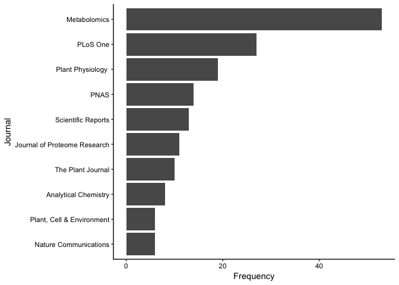

```r
ggplot(OpenDataJournalsOrder[1:10,], aes(reorder(Journal,Frequency), Frequency))  +
  geom_bar(stat = "identity") +
  xlab("Journal") +
  coord_flip() +
  theme_bw() +
  theme(
    axis.text = element_text(colour = "black"),
    #axis.text.x = element_text(angle = 90, hjust = 1),
    axis.line.x = element_line(color="black", size = 0.5),
    axis.line.y = element_line(color="black", size = 0.5),
    # Remove gridlines and borders
    panel.grid.major = element_blank(),
    panel.grid.minor = element_blank(),
    panel.border = element_blank(),
    panel.background = element_blank(),
    legend.position="none")
```

## 4.2 Figure 2. The ten journals with the highest frequency of publications when searching PubMed for “metabolome” OR “metabolomics”.

Having removed all reviews and systematic reviews to leave only journal articles.

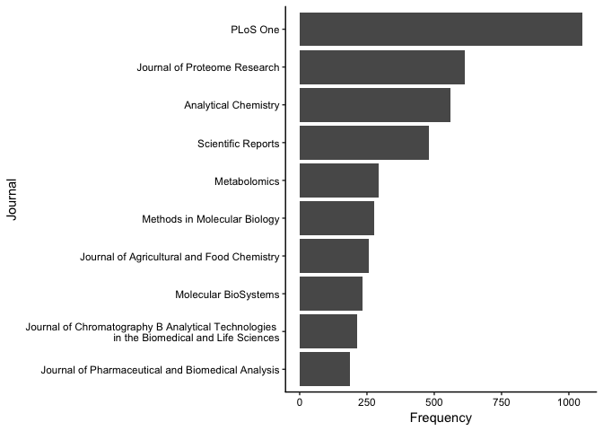

```r
PubmedCorr$Journal <- gsub("J Chromatogr B Analyt Technol Biomed Life Sci", "Journal of Chromatography B Analytical Technologies \n in the Biomedical and Life Sciences", PubmedCorr$Journal, ignore.case=T)

AllJournals <- as.data.frame(table(PubmedCorr$Journal))

# 10 Most common journals for metabolomics data to be published in (All terms)
AllJournalsOrdered <- AllJournals[order(-AllJournals$Freq),]
colnames(AllJournalsOrdered) <- c("Journal", "Frequency")

ggplot(AllJournalsOrdered[1:10,], aes(reorder(Journal,Frequency), Frequency))  +
  geom_bar(stat = "identity") +
  xlab("Journal") +
  coord_flip() +
  theme_bw() +
  theme(
    axis.text = element_text(colour = "black"),
    #axis.text.x = element_text(angle = 90, hjust = 1),
    axis.line.x = element_line(color="black", size = 0.5),
    axis.line.y = element_line(color="black", size = 0.5),
    # Remove gridlines and borders
    panel.grid.major = element_blank(),
    panel.grid.minor = element_blank(),
    panel.border = element_blank(),
    panel.background = element_blank(),
    legend.position="none")
```